HUIJZER.XYZ

# Collinear Bayes

2021-11-17

In my post on Shapley values and multicollinearity, I looked into what happens when you fit a complex uninterpretable model on collinear or *near*-collinear data and try to figure out which features (variables) are important. The results were reasonable but not great. Luckily, there are still more things to try. Gelman et al. ([2020](https://doi.org/10.1017/9781139161879)) say that Bayesian models can do reasonably well on collinear data because they show high uncertainty in the estimated coefficients. Also, Bayesian models have a chance of fitting the data better as is beautifully shown in the [Stan documentation](https://mc-stan.org/users/documentation/case-studies/golf.html). It can be quite tricky to implement though because a good parameterization is necessary (https://statmodeling.stat.columbia.edu/2019/07/07/collinearity-in-bayesian-models/).

## Simulating data

Let's simulate some data with various columns are increasingly correlated with the outcome (and thus each other). Here, we assume that the data is centered around zero. This is easier for the Bayesian model to work with, but can often also make interpretation of the coefficients easier. There are various methods to rescale data, one is using `MLDataUtils: rescale!`. Note that `rescale!` bases the rescaling on the sample which is not recommended for small samples (Gelman, [2020](https://doi.org/10.1017/9781139161879)). Instead, you can use knowledge that you have about the data such as the range of questionnaire scores or the weight of cars. Specifically, for example, it could be known for the data that the weight of a car is never below zero and unlikely to be above 3*600 kg (8*000 lbs); the weight of a Hummer H1.

```julia
begin
	using CairoMakie
	using CategoricalArrays: categorical
	using DataFrames: Not, DataFrame, select, stack, transform
	using GLM
	using Pkg: dependencies
	using Turing
	using Random: seed!
	using Statistics: rand, mean, cor
end
```

```julia
indexes = 1.0:150.0;
```

```julia
y_true(x) = x / last(indexes);
```

```julia
y_noise(x, corr_coefficient) = (corr_coefficient * y_true(x) - 0.5) + rand(Normal(0, 0.15));
```

```julia
df = let
    seed!(0)
    X = indexes
	A = y_noise.(indexes, 0)
    B = y_noise.(indexes, 0.05)
    C = y_noise.(indexes, 0.7)
    D = y_noise.(indexes, 1)
    E = y_noise.(indexes, 1)
    Y = y_noise.(indexes, 1)

    DataFrame(; X, A, B, C, D, E, Y)
end
```

| X | A | B | C | D | E | Y |
| --- | --- | --- | --- | --- | --- | --- |
| 1.0 | -0.398134 | -0.646597 | -0.287546 | -0.619254 | -0.638229 | -0.39991 |
| 2.0 | -0.375738 | -0.613373 | -0.559512 | -0.557565 | -0.485595 | -0.263193 |
| 3.0 | -0.552951 | -0.345602 | -0.584484 | -0.633103 | -0.457123 | -0.687579 |
| 4.0 | -0.520228 | -0.623517 | -0.557895 | -0.365136 | -0.430439 | -0.610894 |
| 5.0 | -0.412007 | -0.714773 | -0.549119 | -0.703409 | -0.41053 | -0.543717 |
| 6.0 | -0.4554 | -0.695053 | -0.467523 | -0.206198 | -0.493009 | -0.34151 |
| 7.0 | -0.490258 | -0.475825 | -0.538481 | -0.638859 | -0.180081 | -0.411017 |
| 8.0 | -0.516353 | -0.300344 | -0.282276 | -0.53808 | -0.370375 | -0.419228 |
| 9.0 | -0.577132 | -0.712678 | -0.550842 | -0.379812 | -0.406112 | -0.434307 |
| 10.0 | -0.26385 | -0.599433 | -0.557579 | -0.333038 | -0.4417 | -0.427372 |
| ... |  |  |  |  |  |  |
| 150.0 | -0.554532 | -0.428804 | 0.160114 | 0.616068 | 0.413887 | 0.688722 |

The data and the correlations look as follows:

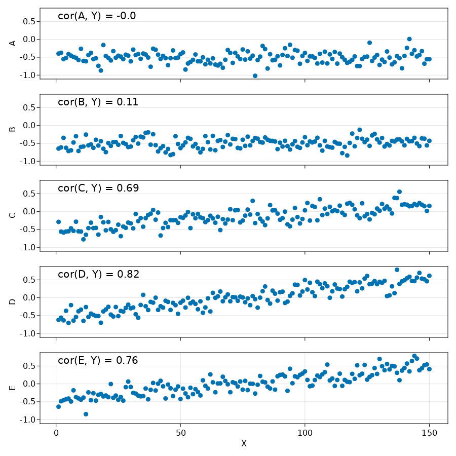

## Defining the model

This is a basic linear regression model similar to the one mentioned in the tutorials on https://turing.ml. The priors of this model are visualized below.

```julia
@model function linear_regression(X::Matrix, y)
	σ₂ ~ truncated(Normal(0, 100), 0, Inf)

	intercept ~ Normal(0, 0.4)

	n_features = size(X, 2)
    coef ~ MvNormal(n_features, 0.4)

	mu = intercept .+ X * coef
    y ~ MvNormal(mu, sqrt(σ₂))
end;
```

```julia
X = select(df, Not([:X, :Y]));
```

```julia
model = let
	y = df.Y
	model = linear_regression(Matrix(X), y)
end;
```

# Inspecting the prior

To verify that the priors are correctly set, we can use `sample(model, Prior(), n_samples)` from Turing.jl. This is shown below with the raw sample values on the left and the density plot for these values on the right.

```julia
n_samples = 1_000;
```

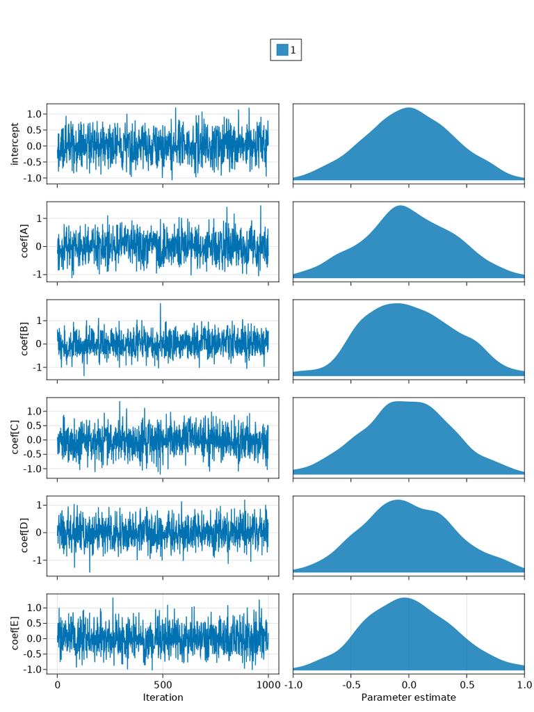

```julia
function mysample(model, sampler)
	n_chains = 3
	chns = sample(model, sampler, MCMCThreads(), n_samples, n_chains)
	return fix_names(chns)
end;
```

## Estimating the parameters

When we fit the model, we have to decide on a sampler for this complex collinear case. NUTS is normally the best bet in Turing.jl, but let's first try HMC.

In the plots below, the different colors indicate different chains. All plots show good mixing and stationarity on the leftmost plots; the chains properly converged to the same outcome:

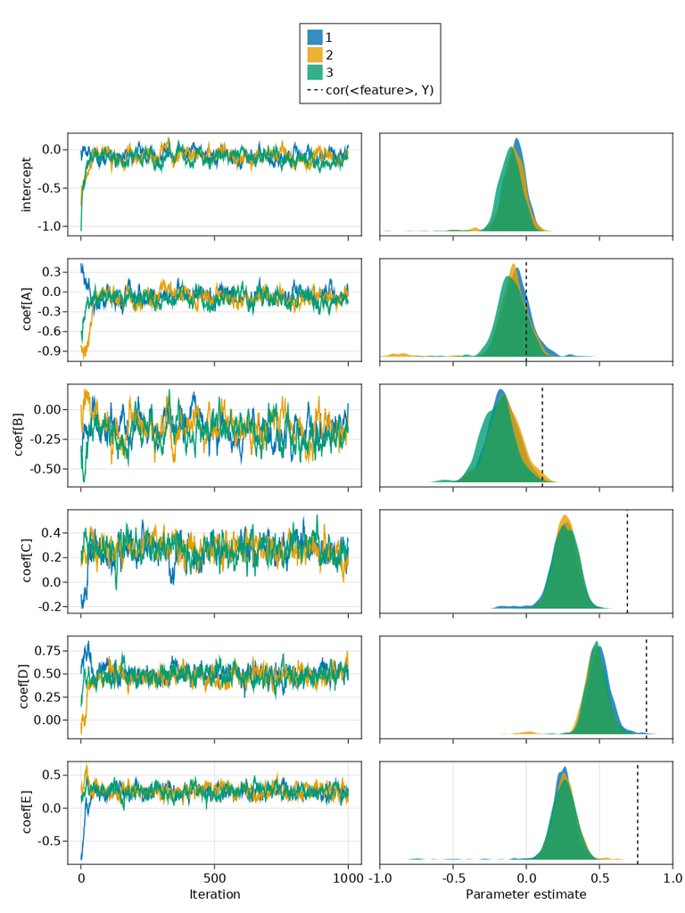

```julia
let
	chns = mysample(model, HMC(0.005, 10))
	plot_chain(chns)
end
```

Obtaining this outcome required setting the leapfrog size to a very low number. Normally, it is 0.05 or 0.1 which both **did not work**. What I mean by did not work is that the different chains did not converge, that is, gave different outcomes. Note that, thanks to the low leapfrog size, it took quite a few iterations for the chains to converge.

Let's try a more modern sampler, namely NUTS:

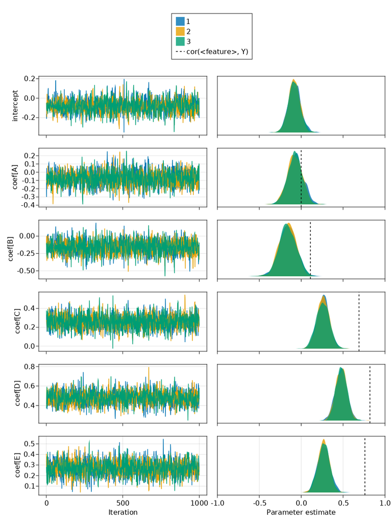

```julia
let
	chns = mysample(model, NUTS())
	plot_chain(chns)
end
```

Compared to the Shapley values, this result is very promising. Both samplers correctly identified the most important coefficient and give reasonable estimates for all the coefficients. In the Shapley post, the most informative feature got too much credit compared to a slightly less informative feature.

## GLM

As a sanity check, let's see what a Frequentists linear model concludes.

```julia
fitted_lm = lm(@formula(Y ~ A + B + C + D + E), df);
```

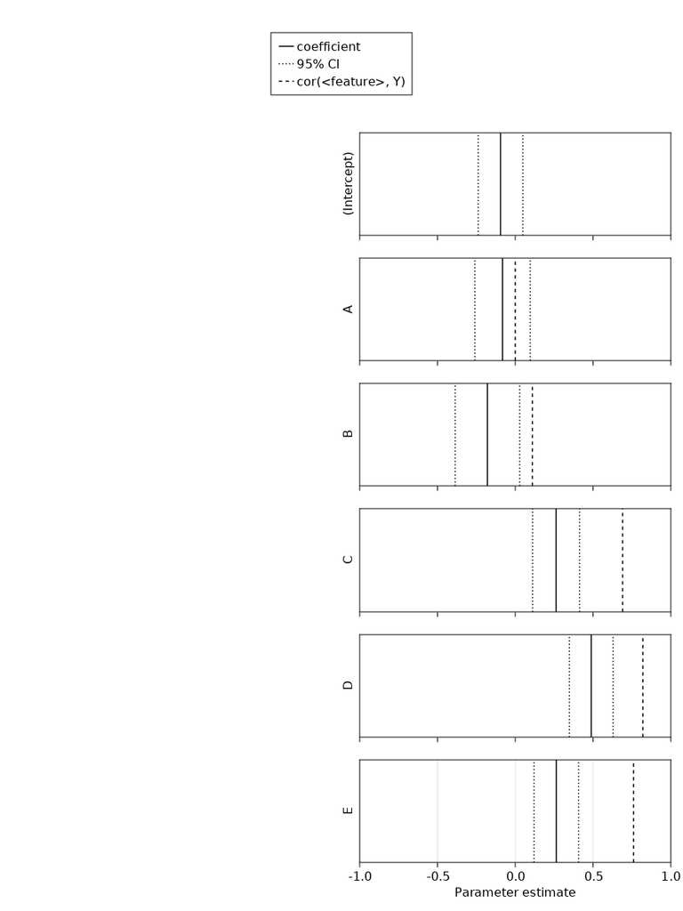

These outcomes are almost the same as the Bayesian output.

## Discussion

Hmm. That's not what I expected. The outcomes for both models are **nearly identical**!

After me retreating to the Julia forum, [Michael Creel](https://discourse.julialang.org/t/multicollinearity-and-glm/71340/5) kindly offered an answer to this. It turned out that Bayesian priors can help with things like multicollinearity, but only if the prior provides enough information to counter the imprecision.

This seems to go back again to my post on Frequentist and Bayesian coin flipping, see the last two figures. When there is a strong prior or weak data, then the Bayesian outcome will differ from the Frequentist one (also mentioned by Gelman, [2020](https://doi.org/10.1017/9781139161879)). Apparently, here the data was pretty strong or the priors pretty weak.

So, the Frequentist and Bayesian world aren't so different. In many cases, they yield the same conclusions.

## Packages

```
CairoMakie 0.6.6
CategoricalArrays 0.10.2
DataFrames 1.2.2
GLM 1.5.1
Turing 0.19.0
```

*This blog post was built via a Pluto.jl notebook*.

[CC BY-SA 4.0](http://creativecommons.org/licenses/by-sa/4.0/) Rik Huijzer. Website built with Franklin.jl and the [Julia programming language](https://julialang.org). Last update: 2021-11-17.